# Time Series HW11

B082040005 高念慈

2023-05-12

## 1.

Consider the daily simple returns of IBM stock, CRSP value-weighted  
index, CRSP equal-weighted index, and the S&P composite index  
from January 1980 to December 2008. The index returns include  
dividend distributions. The data file is d-ibm3dxwkdays8008.txt,  
which has 12 columns. The columns are (year, month, day, IBM, VW,  
EW, SP, M, T, W, H, F), where M, T, W, R, and F denotes indicator  
variables for Monday to Friday, respectively.

### the daily simple returns

```r
data4 = read.table("https://faculty.chicagobooth.edu/-/media/faculty/ruey-s-tsay/teaching/fts3/d-ibm3dxwkdays8008.txt", header=T)
head(data4)
```

```
##   year mom day       ibm        vw        ew        sp M T W R F
## 1 1980   1   2 -0.029126 -0.020089 -0.011686 -0.020196 0 0 1 0 0
## 2 1980   1   3  0.016000 -0.006510 -0.011628 -0.005106 0 0 0 1 0
## 3 1980   1   4 -0.001969  0.013735  0.015809  0.012355 0 0 0 0 1
## 4 1980   1   7 -0.003945  0.004368  0.007013  0.002722 1 0 0 0 0
## 5 1980   1   8  0.067327  0.019340  0.014152  0.020036 0 1 0 0 0
## 6 1980   1   9 -0.029685  0.001714  0.007452  0.000918 0 0 1 0 0
```

1. Use a regression model  
   to study the effects of trading days on the equal-weighted index returns.  
   What is the fitted model? Are the weekday effects significant in the  
   returns at the 5% level?

### What is the fitted model?

```r
ml = lm(ew ~ M+T+W+R+F, data=data4)
summary(ml)
```

```
##
## Call:
## lm(formula = ew ~ M + T + W + R + F, data = data4)
##
## Residuals:
##       Min        1Q    Median        3Q       Max
## -0.102962 -0.003094  0.000533  0.003795  0.108319
##
## Coefficients: (1 not defined because of singularities)
##               Estimate Std. Error t value Pr(>|t|)
## (Intercept)  0.0022386  0.0002155  10.389  < 2e-16 ***
## M           -0.0031734  0.0003085 -10.286  < 2e-16 ***
## T           -0.0019778  0.0003028  -6.532 6.94e-11 ***
## W           -0.0010185  0.0003027  -3.365 0.000770 ***
## R           -0.0010294  0.0003042  -3.384 0.000719 ***
## F                   NA         NA      NA       NA
## ---
## Signif. codes:  0 '***' 0.001 '**' 0.01 '*' 0.05 '.' 0.1 ' ' 1
##
## Residual standard error: 0.008234 on 7314 degrees of freedom
## Multiple R-squared:  0.01618,    Adjusted R-squared:  0.01564
## F-statistic: 30.06 on 4 and 7314 DF,  p-value: < 2.2e-16
```

```r
step(ml)
```

```
## Start:  AIC=-70250.08
## ew ~ M + T + W + R + F
##
##
## Step:  AIC=-70250.08
## ew ~ M + T + W + R
##
##        Df Sum of Sq     RSS    AIC
## <none>              0.49586 -70250
## - W     1 0.0007675 0.49663 -70241
## - R     1 0.0007762 0.49664 -70241
## - T     1 0.0028923 0.49876 -70210
## - M     1 0.0071735 0.50304 -70147
```

```
##
## Call:
## lm(formula = ew ~ M + T + W + R, data = data4)
##
## Coefficients:
## (Intercept)            M            T            W            R
##    0.002239    -0.003173    -0.001978    -0.001019    -0.001029
```

```r
ml2 = lm(ew ~ M+T+W+F+R, data=data4)
summary(ml2)
```

```
##
## Call:
## lm(formula = ew ~ M + T + W + F + R, data = data4)
##
## Residuals:
##       Min        1Q    Median        3Q       Max
## -0.102962 -0.003094  0.000533  0.003795  0.108319
##
## Coefficients: (1 not defined because of singularities)
##               Estimate Std. Error t value Pr(>|t|)
## (Intercept)  0.0012092  0.0002148   5.631 1.86e-08 ***
## M           -0.0021440  0.0003080  -6.961 3.67e-12 ***
## T           -0.0009484  0.0003023  -3.137 0.001711 **
## W            0.0000109  0.0003022   0.036 0.971239
## F            0.0010294  0.0003042   3.384 0.000719 ***
## R                   NA         NA      NA       NA
## ---
## Signif. codes:  0 '***' 0.001 '**' 0.01 '*' 0.05 '.' 0.1 ' ' 1
##
## Residual standard error: 0.008234 on 7314 degrees of freedom
## Multiple R-squared:  0.01618,    Adjusted R-squared:  0.01564
## F-statistic: 30.06 on 4 and 7314 DF,  p-value: < 2.2e-16
```

```r
step(ml2)
```

```
## Start:  AIC=-70250.08
## ew ~ M + T + W + F + R
##
##
## Step:  AIC=-70250.08
## ew ~ M + T + W + F
##
##        Df Sum of Sq     RSS    AIC
## - W     1 0.0000001 0.49586 -70252
## <none>              0.49586 -70250
## - T     1 0.0006673 0.49653 -70242
## - F     1 0.0007762 0.49664 -70241
## - M     1 0.0032852 0.49915 -70204
##
## Step:  AIC=-70252.08
## ew ~ M + T + F
##
##        Df Sum of Sq     RSS    AIC
## <none>              0.49586 -70252
## - T     1 0.0009061 0.49677 -70241
## - F     1 0.0010262 0.49689 -70239
## - M     1 0.0043768 0.50024 -70190
```

```
##
## Call:
## lm(formula = ew ~ M + T + F, data = data4)
##
## Coefficients:
## (Intercept)            M            T            F
##   0.0012147   -0.0021495   -0.0009539    0.0010239
```

```r
ml3 = lm(ew ~ M+T+F+R+W, data=data4)
summary(ml3)
```

```
##
## Call:
## lm(formula = ew ~ M + T + F + R + W, data = data4)
##
## Residuals:
##       Min        1Q    Median        3Q       Max
## -0.102962 -0.003094  0.000533  0.003795  0.108319
##
## Coefficients: (1 not defined because of singularities)
##               Estimate Std. Error t value Pr(>|t|)
## (Intercept)  0.0012201  0.0002126   5.739 9.91e-09 ***
## M           -0.0021549  0.0003065  -7.031 2.24e-12 ***
## T           -0.0009593  0.0003008  -3.190  0.00143 **
## F            0.0010185  0.0003027   3.365  0.00077 ***
## R           -0.0000109  0.0003022  -0.036  0.97124
## W                   NA         NA      NA       NA
## ---
## Signif. codes:  0 '***' 0.001 '**' 0.01 '*' 0.05 '.' 0.1 ' ' 1
##
## Residual standard error: 0.008234 on 7314 degrees of freedom
## Multiple R-squared:  0.01618,    Adjusted R-squared:  0.01564
## F-statistic: 30.06 on 4 and 7314 DF,  p-value: < 2.2e-16
```

```r
step(ml3)
```

```
## Start:  AIC=-70250.08
## ew ~ M + T + F + R + W
##
##
## Step:  AIC=-70250.08
## ew ~ M + T + F + R
##
##        Df Sum of Sq     RSS    AIC
## - R     1 0.0000001 0.49586 -70252
## <none>              0.49586 -70250
## - T     1 0.0006897 0.49655 -70242
## - F     1 0.0007675 0.49663 -70241
## - M     1 0.0033513 0.49922 -70203
##
## Step:  AIC=-70252.08
## ew ~ M + T + F
##
##        Df Sum of Sq     RSS    AIC
## <none>              0.49586 -70252
## - T     1 0.0009061 0.49677 -70241
## - F     1 0.0010262 0.49689 -70239
## - M     1 0.0043768 0.50024 -70190
```

```
##
## Call:
## lm(formula = ew ~ M + T + F, data = data4)
##
## Coefficients:
## (Intercept)            M            T            F
##   0.0012147   -0.0021495   -0.0009539    0.0010239
```

```r
ml4 = lm(ew ~ M+W+F+R+T, data=data4)
summary(ml4)
```

```
##
## Call:
## lm(formula = ew ~ M + W + F + R + T, data = data4)
##
## Residuals:
##       Min        1Q    Median        3Q       Max
## -0.102962 -0.003094  0.000533  0.003795  0.108319
##
## Coefficients: (1 not defined because of singularities)
##               Estimate Std. Error t value Pr(>|t|)
## (Intercept)  0.0002608  0.0002127   1.226  0.22028
## M           -0.0011956  0.0003066  -3.900 9.72e-05 ***
## W            0.0009593  0.0003008   3.190  0.00143 **
## F            0.0019778  0.0003028   6.532 6.94e-11 ***
## R            0.0009484  0.0003023   3.137  0.00171 **
## T                   NA         NA      NA       NA
## ---
## Signif. codes:  0 '***' 0.001 '**' 0.01 '*' 0.05 '.' 0.1 ' ' 1
##
## Residual standard error: 0.008234 on 7314 degrees of freedom
## Multiple R-squared:  0.01618,    Adjusted R-squared:  0.01564
## F-statistic: 30.06 on 4 and 7314 DF,  p-value: < 2.2e-16
```

```r
step(ml4)
```

```
## Start:  AIC=-70250.08
## ew ~ M + W + F + R + T
##
##
## Step:  AIC=-70250.08
## ew ~ M + W + F + R
##
##        Df  Sum of Sq     RSS    AIC
## <none>               0.49586 -70250
## - R     1 0.00066734 0.49653 -70242
## - W     1 0.00068972 0.49655 -70242
## - M     1 0.00103096 0.49689 -70237
## - F     1 0.00289230 0.49876 -70210
```

```
##
## Call:
## lm(formula = ew ~ M + W + F + R, data = data4)
##
## Coefficients:
## (Intercept)            M            W            F            R
##   0.0002608   -0.0011956    0.0009593    0.0019778    0.0009484
```

```r
ml5 = lm(ew ~ T+W+F+R+M, data=data4)
summary(ml5)
```

```
##
## Call:
## lm(formula = ew ~ T + W + F + R + M, data = data4)
##
## Residuals:
##       Min        1Q    Median        3Q       Max
## -0.102962 -0.003094  0.000533  0.003795  0.108319
##
## Coefficients: (1 not defined because of singularities)
##               Estimate Std. Error t value Pr(>|t|)
## (Intercept) -0.0009348  0.0002208  -4.234 2.32e-05 ***
## T            0.0011956  0.0003066   3.900 9.72e-05 ***
## W            0.0021549  0.0003065   7.031 2.24e-12 ***
## F            0.0031734  0.0003085  10.286  < 2e-16 ***
## R            0.0021440  0.0003080   6.961 3.67e-12 ***
## M                   NA         NA      NA       NA
## ---
## Signif. codes:  0 '***' 0.001 '**' 0.01 '*' 0.05 '.' 0.1 ' ' 1
##
## Residual standard error: 0.008234 on 7314 degrees of freedom
## Multiple R-squared:  0.01618,    Adjusted R-squared:  0.01564
## F-statistic: 30.06 on 4 and 7314 DF,  p-value: < 2.2e-16
```

```r
step(ml5)
```

```
## Start:  AIC=-70250.08
## ew ~ T + W + F + R + M
##
##
## Step:  AIC=-70250.08
## ew ~ T + W + F + R
##
##        Df Sum of Sq     RSS    AIC
## <none>              0.49586 -70250
## - T     1 0.0010310 0.49689 -70237
## - R     1 0.0032852 0.49915 -70204
## - W     1 0.0033513 0.49922 -70203
## - F     1 0.0071735 0.50304 -70147
```

```
##
## Call:
## lm(formula = ew ~ T + W + F + R, data = data4)
##
## Coefficients:
## (Intercept)            T            W            F            R
##  -0.0009348    0.0011956    0.0021549    0.0031734    0.0021440
```

- AIC 最低的模型:lm(formula = ew ~ M + T + F, data = data4)

```r
best = lm(formula = ew ~ M + T + F, data = data4)
summary(best)
```

```
##
## Call:
## lm(formula = ew ~ M + T + F, data = data4)
##
## Residuals:
##       Min        1Q    Median        3Q       Max
## -0.102962 -0.003094  0.000533  0.003792  0.108319
##
## Coefficients:
##               Estimate Std. Error t value Pr(>|t|)
## (Intercept)  0.0012147  0.0001511   8.040 1.04e-15 ***
## M           -0.0021495  0.0002675  -8.035 1.08e-15 ***
## T           -0.0009539  0.0002609  -3.656 0.000258 ***
## F            0.0010239  0.0002632   3.891 0.000101 ***
## ---
## Signif. codes:  0 '***' 0.001 '**' 0.01 '*' 0.05 '.' 0.1 ' ' 1
##
## Residual standard error: 0.008233 on 7315 degrees of freedom
## Multiple R-squared:  0.01617,    Adjusted R-squared:  0.01577
## F-statistic: 40.09 on 3 and 7315 DF,  p-value: < 2.2e-16
```

### Are the weekday effects significant in the returns at the 5% level?

- 星期一、二、五在上面每個模型中，p-value 均小於0.05，故這幾天顯著影響報酬率
- 但其實大部分的模型每天對報酬率都有顯著影響，AIC間也變化不大
2. Use the HAC estimator of the covariance matrix to obtain the t ratio of  
   regression estimates. Does the HAC estimator change the conclusion of weekday effects?

```r
coeftest(best, vcov=vcovHAC(best))
```

```
##
## t test of coefficients:
##
##                Estimate  Std. Error t value  Pr(>|t|)
## (Intercept)  0.00121469  0.00014725  8.2494 < 2.2e-16 ***
## M           -0.00214947  0.00030064 -7.1496 9.548e-13 ***
## T           -0.00095390  0.00024974 -3.8196 0.0001348 ***
## F            0.00102393  0.00024262  4.2204 2.468e-05 ***
## ---
## Signif. codes:  0 '***' 0.001 '**' 0.01 '*' 0.05 '.' 0.1 ' ' 1
```

- By using the HAC estimator, it doesn’t change the conclusion of weekday effects.
- 仍是 M、T、F 影響顯著

## 2.

Now consider similar questions of the previous exercise for the IBM  
stock returns.(d-ibm3dxwkdays8008.txt)

3. Refine the above model by using the technique of regression model  
   with time series errors. In there a significant weekday effect based  
   on the refined model?

```r
ibm = lm(ibm ~ M + T + W + R + F ,data=data4)
summary(ibm)
```

```
##
## Call:
## lm(formula = ibm ~ M + T + W + R + F, data = data4)
##
## Residuals:
##       Min        1Q    Median        3Q       Max
## -0.231629 -0.009290 -0.000036  0.008840  0.131619
##
## Coefficients: (1 not defined because of singularities)
##               Estimate Std. Error t value Pr(>|t|)
## (Intercept) -0.0005902  0.0004671  -1.264 0.206382
## M            0.0025896  0.0006687   3.873 0.000109 ***
## T            0.0020296  0.0006563   3.092 0.001992 **
## W            0.0002289  0.0006561   0.349 0.727217
## R            0.0006073  0.0006594   0.921 0.357085
## F                   NA         NA      NA       NA
## ---
## Signif. codes:  0 '***' 0.001 '**' 0.01 '*' 0.05 '.' 0.1 ' ' 1
##
## Residual standard error: 0.01785 on 7314 degrees of freedom
## Multiple R-squared:  0.003269,   Adjusted R-squared:  0.002723
## F-statistic: 5.996 on 4 and 7314 DF,  p-value: 8.178e-05
```

- model:$R_t = -0.0005902 + 0.0025896M + 0.0020296T + 0.0002289W + 0.0006073R$
- 星期一和星期二在不考慮星期五影響下 p-value < 0.05，顯著影響報酬率

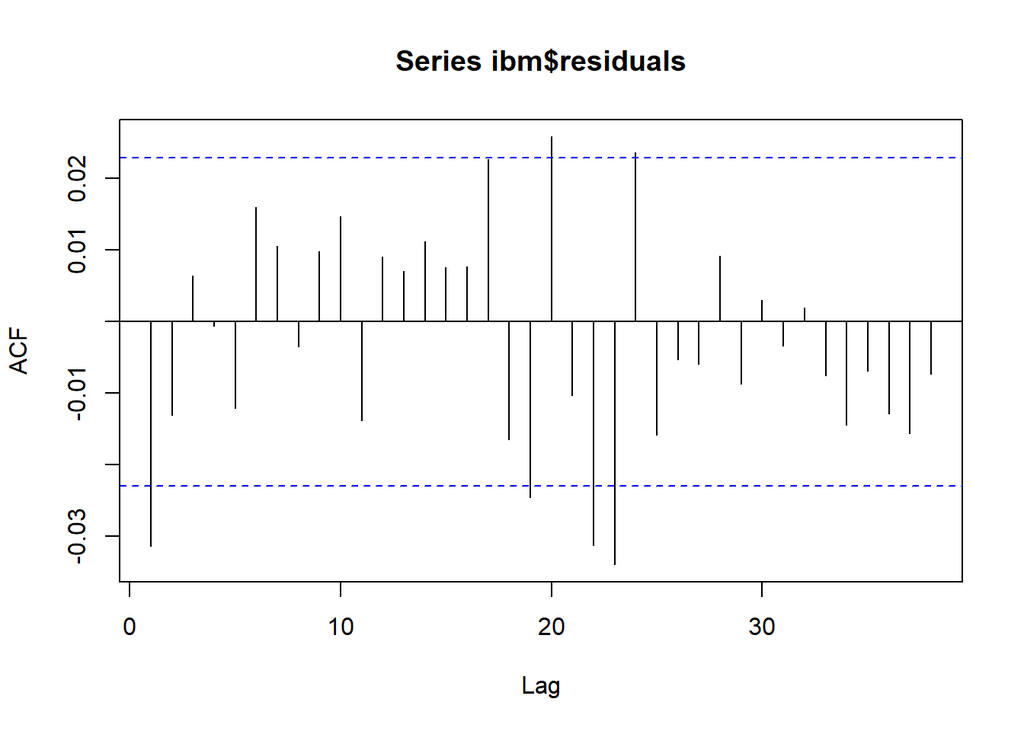

```r
acf(ibm$residuals)
```

### serial correlations in the residuals

- Use Q(12) to perform the test

```r
Box.test(ibm$residuals,lag=12,type='Ljung')
```

```
##
##  Box-Ljung test
##
## data:  ibm$residuals
## X-squared = 16.845, df = 12, p-value = 0.1555
```

- NO，因為 p-value > 0.05，不拒絕 H0 (無序列相關)

```r
eacf(ibm$residuals)
```

```
## AR/MA
##   0 1 2 3 4 5 6 7 8 9 10 11 12 13
## 0 x o o o o o o o o o o  o  o  o
## 1 x x o o o o o o o o o  o  o  o
## 2 x x o o o o o o o o o  o  o  o
## 3 x x x o o o o o o o o  o  o  o
## 4 x x o x o o o o o o o  o  o  o
## 5 x x o x x o o o o o o  o  o  o
## 6 x x x o x x o o o o o  o  o  o
## 7 x x x o x x x o o o o  o  o  o
```

### MA(1)

```r
estmodel1 = arima(data4$ibm, order = c(0,0,1),
                  xreg = data4$M + data4$T)
estmodel1
```

```
##
## Call:
## arima(x = data4$ibm, order = c(0, 0, 1), xreg = data4$M + data4$T)
##
## Coefficients:
##           ma1  intercept   xreg
##       -0.0323     -3e-04  2e-03
## s.e.   0.0118      3e-04  4e-04
##
## sigma^2 estimated as 0.000318:  log likelihood = 19086.27,  aic = -38166.53
```

```r
rbind(estmodel1$coef-2*sqrt(diag(estmodel1$var.coef)),estmodel1$coef+2*sqrt(diag(estmodel1$var.coef)))
```

```
##               ma1     intercept        xreg
## [1,] -0.055990572 -0.0008361281 0.001170257
## [2,] -0.008665408  0.0002139907 0.002869598
```

```r
estmodel2 = arima(data4$ibm, order = c(0,0,1),
                  xreg = data4$M + data4$T,
                  fixed=c(NA,0,NA))
estmodel2
```

```
##
## Call:
## arima(x = data4$ibm, order = c(0, 0, 1), xreg = data4$M + data4$T, fixed = c(NA,
##     0, NA))
##
## Coefficients:
##           ma1  intercept    xreg
##       -0.0322          0  0.0017
## s.e.   0.0118          0  0.0003
##
## sigma^2 estimated as 0.0003181:  log likelihood = 19085.57,  aic = -38167.15
```

```r
Box.test(estmodel2$residuals, lag=12, type="Ljung")
```

```
##
##  Box-Ljung test
##
## data:  estmodel2$residuals
## X-squared = 9.4467, df = 12, p-value = 0.6644
```

```r
estmodel2$coef
```

```
##         ma1   intercept        xreg
## -0.03224112  0.00000000  0.00169704
```

```r
estmodel2$var.coef
```

```
##               ma1         xreg
## ma1  1.399566e-04 6.153852e-08
## xreg 6.153852e-08 1.068652e-07
```

$$H_0 : \beta = 0$$
$$t =
\frac{\hat{\beta}-0}{stdev(\hat{\beta})}$$

```r
t_ibm = estmodel2$coef[3]/sqrt(estmodel2$var.coef[2,2])
t_ibm
```

```
##     xreg
## 5.191273
```

```r
p_value = 2*(1-pnorm(t_ibm))
cbind(test_statistic=t_ibm, p_value=p_value)
```

```
##      test_statistic      p_value
## xreg       5.191273 2.088611e-07
```

- There is a significant weekday effect based on the refined model since p-value < 0.05

## 3.

Again, consider the two bond yield series, that is, Aaa and Baa. What  
is the relationship between the two series? To answer this question,  
build a time series model using yields of Aaa bonds as the dependent  
variable and yields of Baa bonds as independent variable

```r
Aaa = read.table("C:/Users/user/Desktop/time_series/HW/w-Aaa.txt",header = F)
head(Aaa)
```

```
##     V1 V2 V3   V4
## 1 1962  1  5 4.43
## 2 1962  1 12 4.42
## 3 1962  1 19 4.42
## 4 1962  1 26 4.41
## 5 1962  2  2 4.42
## 6 1962  2  9 4.42
```

```r
Baa = read.table("C:/Users/user/Desktop/time_series/HW/w-Baa.txt",header = F)
head(Baa)
```

```
##     V1 V2 V3   V4
## 1 1962  1  5 5.11
## 2 1962  1 12 5.09
## 3 1962  1 19 5.08
## 4 1962  1 26 5.08
## 5 1962  2  2 5.07
## 6 1962  2  9 5.08
```

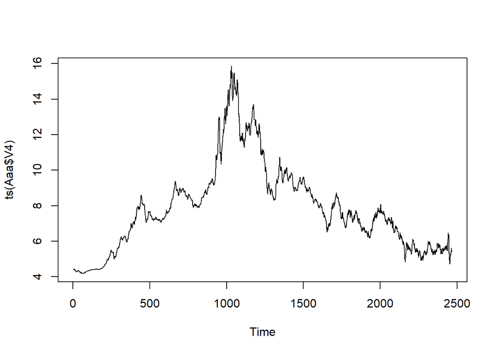

```r
plot(ts(Aaa$V4))
```

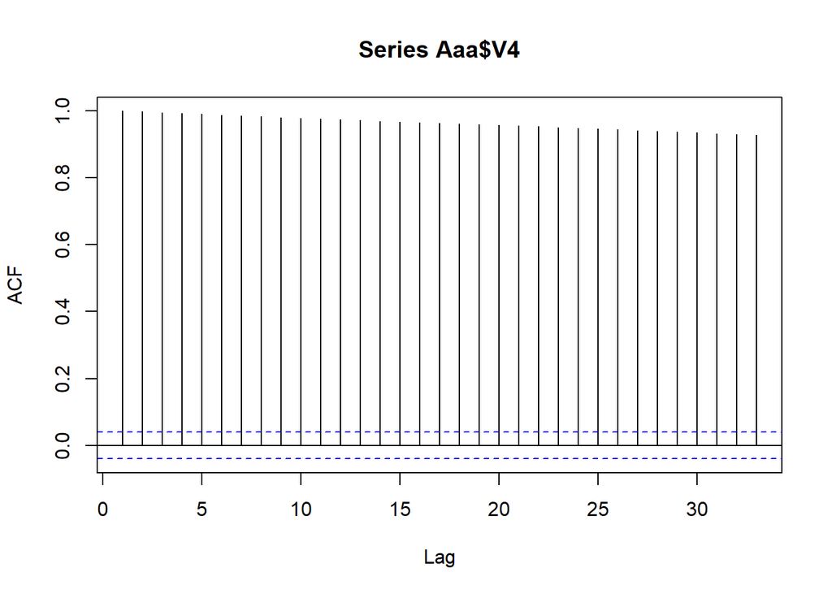

```r
acf(Aaa$V4)
```

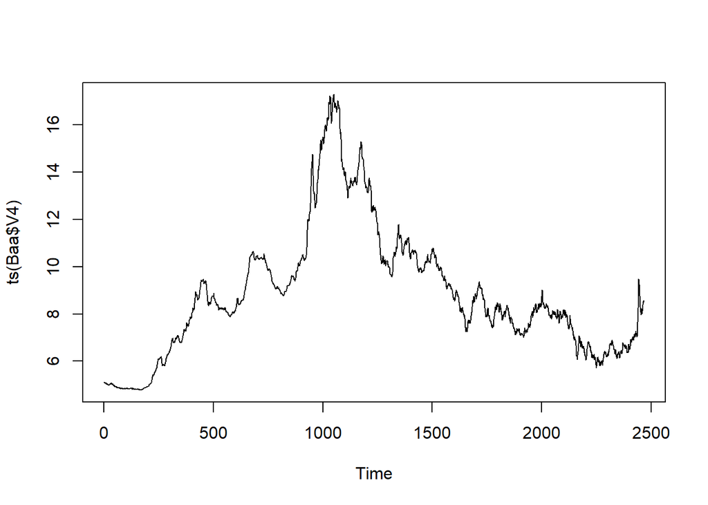

```r
plot(ts(Baa$V4))
```

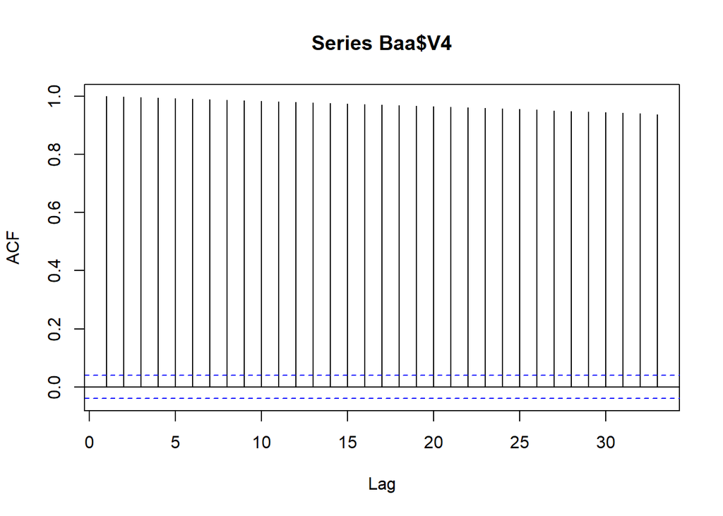

```r
acf(Baa$V4)
```

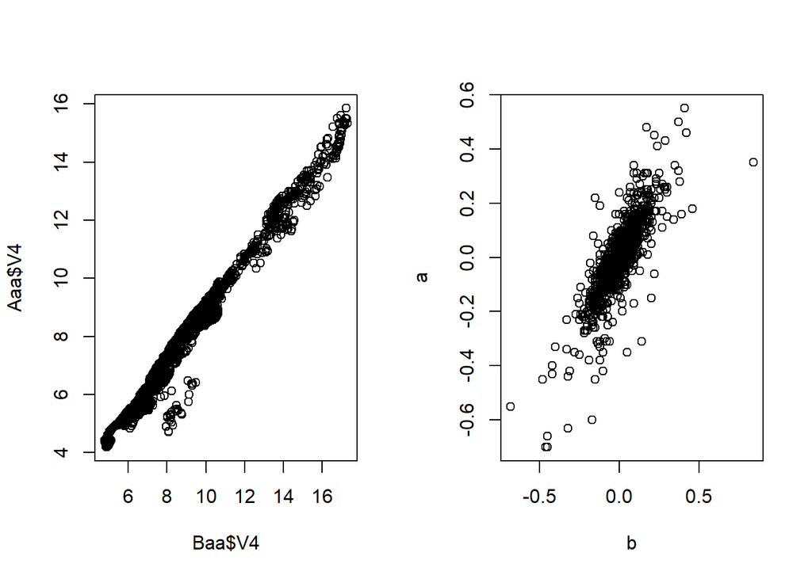

```r
a = diff(Aaa$V4)
b = diff(Baa$V4)

par(mfrow=c(1,2))
plot(Baa$V4,Aaa$V4)
plot(b,a)
```

```r
reg.fit = lm(a ~ -1+b)
summary(reg.fit)
```

```
##
## Call:
## lm(formula = a ~ -1 + b)
##
## Residuals:
##      Min       1Q   Median       3Q      Max
## -0.44475 -0.01838  0.00000  0.01946  0.36192
##
## Coefficients:
##   Estimate Std. Error t value Pr(>|t|)
## b  0.94613    0.01264   74.87   <2e-16 ***
## ---
## Signif. codes:  0 '***' 0.001 '**' 0.01 '*' 0.05 '.' 0.1 ' ' 1
##
## Residual standard error: 0.05341 on 2465 degrees of freedom
## Multiple R-squared:  0.6946, Adjusted R-squared:  0.6944
## F-statistic:  5605 on 1 and 2465 DF,  p-value: < 2.2e-16
```

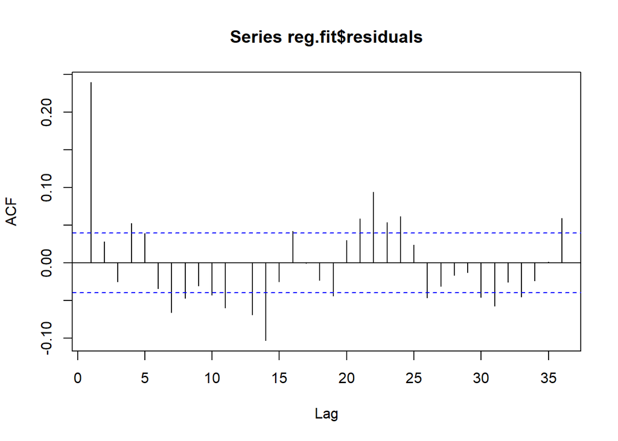

```r
acf(reg.fit$residuals, lag=36)
```

```r
m1 = arima(a, order=c(0,0,1), xreg=b, include.mean=F)
m1
```

```
##
## Call:
## arima(x = a, order = c(0, 0, 1), xreg = b, include.mean = F)
##
## Coefficients:
##          ma1    xreg
##       0.2335  0.9436
## s.e.  0.0185  0.0132
##
## sigma^2 estimated as 0.00269:  log likelihood = 3797.81,  aic = -7591.62
```

```r
rbind(m1$coef-2*sqrt(diag(m1$var.coef)),
      m1$coef+2*sqrt(diag(m1$var.coef)))
```

```
##            ma1      xreg
## [1,] 0.1964290 0.9171835
## [2,] 0.2705052 0.9699801
```

```r
Box.test(m1$residuals, lag=12, type="Ljung")
```

```
##
##  Box-Ljung test
##
## data:  m1$residuals
## X-squared = 43.245, df = 12, p-value = 2.052e-05
```

- p value<0.05，拒絕H0，序列相關，該模型不夠，(不好)

```r
eacf(m1$residuals)
```

```
## AR/MA
##   0 1 2 3 4 5 6 7 8 9 10 11 12 13
## 0 o o x x o o x o o o x  o  x  x
## 1 x o o x x o o o o o x  o  o  x
## 2 x o o x o o o o o o o  o  x  o
## 3 x o x x o o o o o o o  o  x  o
## 4 x x x x o x o o o o o  o  x  x
## 5 x x x x o o o o o o o  o  x  x
## 6 x x x o o o o o o o o  o  o  x
## 7 x x x o o o o o o o o  o  o  x
```

### arima(2,0,4)

```r
m2 = arima(a, order=c(2,0,4), xreg=b, include.mean=F)
m2
```

```
##
## Call:
## arima(x = a, order = c(2, 0, 4), xreg = b, include.mean = F)
##
## Coefficients:
##          ar1      ar2      ma1    ma2     ma3     ma4    xreg
##       0.9238  -0.9649  -0.6831  0.793  0.1817  0.0879  0.9467
## s.e.  0.0114   0.0101   0.0231  0.025  0.0236  0.0206  0.0130
##
## sigma^2 estimated as 0.002631:  log likelihood = 3825.26,  aic = -7636.52
```

```r
rbind(m2$coef-2*sqrt(diag(m2$var.coef)),
      m2$coef+2*sqrt(diag(m2$var.coef)))
```

```
##            ar1        ar2        ma1       ma2       ma3        ma4      xreg
## [1,] 0.9009959 -0.9851984 -0.7293284 0.7430812 0.1344973 0.04675936 0.9206019
## [2,] 0.9465714 -0.9446953 -0.6368022 0.8429703 0.2289060 0.12906066 0.9727363
```

```r
Box.test(m2$residuals, lag=12, type="Ljung")
```

```
##
##  Box-Ljung test
##
## data:  m2$residuals
## X-squared = 37.023, df = 12, p-value = 0.0002215
```

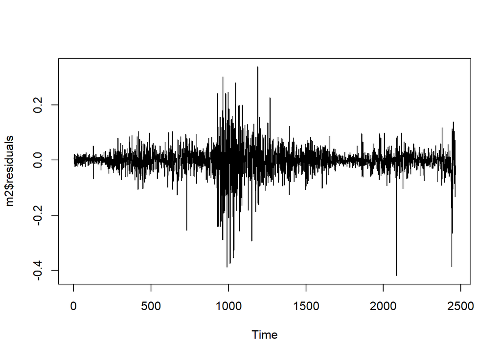

```r
plot(m2$residuals)
```

```r
adfTest(diff(b))
```

```
##
## Title:
##  Augmented Dickey-Fuller Test
##
## Test Results:
##   PARAMETER:
##     Lag Order: 1
##   STATISTIC:
##     Dickey-Fuller: -53.0148
##   P VALUE:
##     0.01
##
## Description:
##  Fri May 12 06:15:17 2023 by user: user
```

- p value<0.05，拒絕H0，序列相關，該模型不夠，(不好)，但有進步

$$H_0 : \beta = 0$$
$$t =
\frac{\hat{\beta}-0}{stdev(\hat{\beta})}$$

```r
m2$coef
```

```
##         ar1         ar2         ma1         ma2         ma3         ma4
##  0.92378369 -0.96494682 -0.68306530  0.79302577  0.18170167  0.08791001
##        xreg
##  0.94666909
```

```r
m2$var.coef
```

```
##                ar1           ar2           ma1           ma2           ma3
## ar1   1.298204e-04 -2.631201e-05 -1.274029e-04  8.196282e-06  3.809453e-05
## ar2  -2.631201e-05  1.025313e-04  3.223757e-05 -8.842491e-05  1.174010e-05
## ma1  -1.274029e-04  3.223757e-05  5.350685e-04 -2.836087e-04  2.435095e-04
## ma2   8.196282e-06 -8.842491e-05 -2.836087e-04  6.236151e-04 -5.428976e-04
## ma3   3.809453e-05  1.174010e-05  2.435095e-04 -5.428976e-04  5.570630e-04
## ma4  -3.603850e-05  3.100050e-05  1.566689e-04  2.498775e-04 -2.674465e-04
## xreg  2.077260e-06  1.153685e-06 -3.485335e-06  2.443752e-05 -2.310582e-05
##                ma4          xreg
## ar1  -3.603850e-05  2.077260e-06
## ar2   3.100050e-05  1.153685e-06
## ma1   1.566689e-04 -3.485335e-06
## ma2   2.498775e-04  2.443752e-05
## ma3  -2.674465e-04 -2.310582e-05
## ma4   4.233441e-04  2.372395e-05
## xreg  2.372395e-05  1.698752e-04
```

```r
t_ibm2 = m2$coef[7]/sqrt(m2$var.coef[7,7])
t_ibm2
```

```
##     xreg
## 72.63286
```

```r
p_value2 = 2*(1-pnorm(t_ibm2))
cbind(test_statistic=t_ibm2, p_value=p_value2)
```

```
##      test_statistic p_value
## xreg       72.63286       0
```

- p-value為0, Aaa、Baa H(A)C 顯著相關